# NLP: Transfer learning for Amazon review word embeddings

```r
knitr::opts_chunk$set(echo = TRUE, cache = FALSE)
```

This project is designed to test your current knowledge on applying word embeddings to the [Amazon Fine Foods reviews](https://snap.stanford.edu/data/web-FineFoods.html) dataset available through Stanford. This dataset contains 568,454 reviews on 74,258 products.

Your goal is to develop a word embedding model to accurately predict how **helpful** a review will be. I supply code to help you get the data imported and prepped so that you can focus on the modeling aspect.

*Good luck!*

# Requirements

```r
library(keras)     # provides deep learning procedures
library(tidyverse) # provides basic data wrangling and visualization
library(glue)      # provides efficient print statements
library(testthat)  # provides unit testing
```

# Data importing

The finefoods.txt.gz file has already been downloaded and unzipped for you. All reviews are contained in a single .txt file.

```r
amazon_reviews <- here::here("docs", "data", "amazon-food", "finefoods.txt")
reviews <- read_lines(amazon_reviews)
```

Each review consists of 8 items and each item is on its own line. The following shows all information collected for the first review.

```r
head(reviews, 8)
```

```
[1] "product/productId: B001E4KFG0"
[2] "review/userId: A3SGXH7AUHU8GW"
[3] "review/profileName: delmartian"
[4] "review/helpfulness: 1/1"
[5] "review/score: 5.0"
[6] "review/time: 1303862400"
[7] "review/summary: Good Quality Dog Food"
[8] "review/text: I have bought several of the Vitality canned dog food products and have found them all to be of good quality. The product looks more like a stew than a processed meat and it smells better. My Labrador is finicky and she appreciates this product better than  most."
```

# Verify we properly imported

Based on the data’s [website](https://snap.stanford.edu/data/web-FineFoods.html), we should have the following:

- Number of reviews: 568,454
- Number of products: 74,258
- Number of users: 256,059

```r
review_text <- reviews[str_detect(reviews, "review/text:")]
products <- reviews[str_detect(reviews, "product/productId:")]
users <- reviews[str_detect(reviews, "review/userId:")]

n_reviews <- length(review_text)
n_products <- n_distinct(products)
n_users <- n_distinct(users)

# Verify our imported data aligns with data codebook
expect_equal(n_reviews, 568454)
expect_equal(n_products, 74258)
expect_equal(n_users, 256059)
```

# Extracting key parts of the data

There are two main parts of these reviews that we need for our modeling purpose:

1. The review text
2. The fraction of users who found the review helpful

## Getting our text

Let’s extract the text

```r
text <- review_text %>%
  str_replace("review/text:", "") %>%
  iconv(to = "UTF-8") %>%
  str_trim()

expect_equal(length(text), n_reviews)

text[1]
```

```
[1] "I have bought several of the Vitality canned dog food products and have found them all to be of good quality. The product looks more like a stew than a processed meat and it smells better. My Labrador is finicky and she appreciates this product better than  most."
```

## Getting our labels

Now let’s extract our helpfulness information. This represents the fraction of users who found the review helpful for a given product.

```r
helpfulness_info <- reviews[str_detect(reviews, "review/helpfulness:")] %>%
  str_extract("\\d.*")

expect_equal(length(helpfulness_info), n_reviews)

head(helpfulness_info)
```

```
[1] "1/1" "0/0" "1/1" "3/3" "0/0" "0/0"
```

Let’s separeate this information into the number of reviews (denominator) and the number of user who found the review helpful (numerator).

```r
num_reviews <- str_replace(helpfulness_info, "^.*\\/", "") %>% as.integer()
helpfulness <- str_replace(helpfulness_info, "\\/.*$", "") %>% as.integer()
```

And we’re only going to care about those products with 10+ reviews to try minimize some of the noise.

```r
num_index <- num_reviews >= 10
num_reviews <- num_reviews[num_index]
helpfulness <- helpfulness[num_index]
text <- text[num_index]

# verify that the number of observations in each vector is equal
expect_equal(
  map_int(list(num_reviews, helpfulness, text), length) %>% n_distinct(),
  1
)

glue("There are {sum(num_index)} reviews that fall in products with 10 or more reviews.")
```

```
There are 24982 reviews that fall in products with 10 or more reviews.
```

Our labels is going to be the fraction provided by helpfulness converted to a percentage.

```r
labels <- helpfulness / num_reviews

expect_equal(length(labels), length(text))

range(labels)
```

```
[1] 0 1
```

```r
cat("First unhelpful review:\n")
```

```
First unhelpful review:
```

```r
first_neg <- first(which(labels == 0))
text[first_neg]
```

```
[1] "I read the reviews on this and thought id get some for my dog and pup.<br />They will not touch it. Even if I mix it with home cooked food.<br /><br />They like the dollar store dog food better than this.<br /><br />Amazon let me down on even allowing this dog food to be sold under their name."
```

```r
cat("\nFirst very helpful review:\n")
```

```
First very helpful review:
```

```r
first_pos <- first(which(labels == 1))
text[first_pos]
```

```
[1] "McCann's Instant Oatmeal is great if you must have your oatmeal but can only scrape together two or three minutes to prepare it. There is no escaping the fact, however, that even the best instant oatmeal is nowhere near as good as even a store brand of oatmeal requiring stovetop preparation.  S…
```

Let’s get a quick assessment of word usage across the reviews:

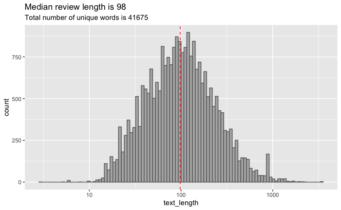

```r
text_df <- text %>%
  tibble(.name_repair = ~ "text") %>%
  mutate(text_length = str_trim(text) %>% str_count("\\w+"))

unique_words <- text_df %>%
  tidytext::unnest_tokens(word, text) %>%
  pull(word) %>%
  n_distinct()

avg_review_length <- median(text_df$text_length, na.rm = TRUE)

ggplot(text_df, aes(text_length)) +
  geom_histogram(bins = 100, fill = "grey70", color = "grey40") +
  geom_vline(xintercept = avg_review_length, color = "red", lty = "dashed") +
  scale_x_log10() +
  ggtitle(glue("Median review length is {avg_review_length}"),
          subtitle = glue("Total number of unique words is {unique_words}"))
```

# Explore Glove Embeddings

We can explore word embeddings that give us some context of the review language.

```r
# helper functions we'll use to explore word embeddings
source("helper_functions.R")

# clean up text and compute word embeddings
clean_text <- tolower(text) %>%
  str_replace_all(pattern = "[[:punct:] ]+", replacement = " ") %>%
  str_trim()

word_embeddings <- get_embeddings(clean_text)
```

```
Creating vocabulary...
Creating term-co-occurence matrix...
Computing embeddings based on GloVe algorithm...
```

```
INFO [2019-11-25 11:10:51] 2019-11-25 11:10:51 - epoch 1, expected cost 0.1424
INFO [2019-11-25 11:10:51] 2019-11-25 11:10:51 - epoch 2, expected cost 0.0977
INFO [2019-11-25 11:10:52] 2019-11-25 11:10:52 - epoch 3, expected cost 0.0857
INFO [2019-11-25 11:10:52] 2019-11-25 11:10:52 - epoch 4, expected cost 0.0780
INFO [2019-11-25 11:10:53] 2019-11-25 11:10:53 - epoch 5, expected cost 0.0728
INFO [2019-11-25 11:10:53] 2019-11-25 11:10:53 - epoch 6, expected cost 0.0689
INFO [2019-11-25 11:10:54] 2019-11-25 11:10:54 - epoch 7, expected cost 0.0660
INFO [2019-11-25 11:10:54] 2019-11-25 11:10:54 - epoch 8, expected cost 0.0636
INFO [2019-11-25 11:10:55] 2019-11-25 11:10:55 - epoch 9, expected cost 0.0618
INFO [2019-11-25 11:10:55] 2019-11-25 11:10:55 - epoch 10, expected cost 0.0603
INFO [2019-11-25 11:10:56] 2019-11-25 11:10:56 - epoch 11, expected cost 0.0589
INFO [2019-11-25 11:10:56] 2019-11-25 11:10:56 - epoch 12, expected cost 0.0578
INFO [2019-11-25 11:10:57] 2019-11-25 11:10:57 - epoch 13, expected cost 0.0569
INFO [2019-11-25 11:10:57] 2019-11-25 11:10:57 - epoch 14, expected cost 0.0560
INFO [2019-11-25 11:10:58] 2019-11-25 11:10:58 - epoch 15, expected cost 0.0552
INFO [2019-11-25 11:10:58] 2019-11-25 11:10:58 - epoch 16, expected cost 0.0545
INFO [2019-11-25 11:10:59] 2019-11-25 11:10:58 - epoch 17, expected cost 0.0539
INFO [2019-11-25 11:10:59] 2019-11-25 11:10:59 - epoch 18, expected cost 0.0534
INFO [2019-11-25 11:10:59] 2019-11-25 11:10:59 - epoch 19, expected cost 0.0529
INFO [2019-11-25 11:10:59] Success: early stopping. Improvement at iterartion 19 is less then convergence_tol
```

Explore your own words!

```r
# find words with similar embeddings
get_similar_words("oil", word_embeddings)
```

```
      oil     olive   coconut      oils vegetable
1.0000000 0.8796831 0.8637189 0.7239558 0.6951106
```

# Prepare data

First, you need to convert the labels to an array.

```r
labels <- as.array(labels)
```

Next, you need to create your tokenizer. Go ahead and start by using the top 20,000 most frequently used words.

```r
top_n_words <- 20000

tokenizer <- text_tokenizer(num_words = top_n_words) %>%
  fit_text_tokenizer(text)

names(tokenizer)
```

```
 [1] "char_level"                   "document_count"               "filters"                      "fit_on_sequences"             "fit_on_texts"
 [6] "get_config"                   "index_docs"                   "index_word"                   "lower"                        "num_words"
[11] "oov_token"                    "sequences_to_matrix"          "sequences_to_texts"           "sequences_to_texts_generator" "split"
[16] "texts_to_matrix"              "texts_to_sequences"           "texts_to_sequences_generator" "to_json"                      "word_counts"
[21] "word_docs"                    "word_index"
```

Next, convert your text to a numerically encoded sequence.

```r
sequences <- texts_to_sequences(tokenizer, text)
```

```r
# The vectorized first instance:
sequences[[1]]
```

```
  [1]  3441   798   716     9    63    29    15   420    20    55   716    17    40    62  4852   841   110    26   227   364     5  1665     8    72     9    49 15978
 [28]     1   351   194    13    83     1   111   798   716     9  2730  1126    21    41    21    83     4   174   183     7   716  5144  3948  2292   138     1  3441
 [55]     9    21    41    21     8   707    12   798   716    43    83   106    57     1   145    35   158   294     2    20   107    35     1   898    10     1  3441
 [82]   427   248    51    41     8    40    27  1450    10     1   949    26    67   735  1569    82    25     8     9  1034    10     1  3242    45    89     9    58
[109]   875     6     6  3441    76     7   965  1498   103   328     7   177   767   259   357  1077    42  1692     5    94    11    31   200   103   168   106     3
[136]     9    18    21  2138    21     1    61   173    33   196     2    78    18    28   250     9  3441    76     7 12410   930   484    82   484   618   163    90
[163]     4   997   407   716   175     1   207    12  4660   809    17    11     9     4  1434    31   359     1  4660   809     9   251    85  1001    10     1   513
[190]     4   190     1   798  3441  2123    93   832     3 14552
```

Run this code chunk to see how your text has been converted:

```r
cat(crayon::blue("Original text:\n"))
```

```
Original text:
```

```r
text[[1]]
```

```
[1] "McCann's Instant Oatmeal is great if you must have your oatmeal but can only scrape together two or three minutes to prepare it. There is no escaping the fact, however, that even the best instant oatmeal is nowhere near as good as even a store brand of oatmeal requiring stovetop preparation.  S…
```

```r
cat(crayon::blue("\nRevised text:\n"))
```

```
Revised text:
```

```r
paste(unlist(tokenizer$index_word)[sequences[[1]]] , collapse = " ")
```

```
[1] "mccann's instant oatmeal is great if you must have your oatmeal but can only scrape together two or three minutes to prepare it there is no escaping the fact however that even the best instant oatmeal is nowhere near as good as even a store brand of oatmeal requiring stovetop preparation still …
```

Go ahead and limit the sequences to only use the first 200 words.

```r
max_len <- 200
features <- pad_sequences(sequences, maxlen = max_len)

expect_equal(ncol(features), 200)
```

Make sure that the number of observations in your features and labels are equal:

```r
expect_equal(nrow(features), length(labels))
```

## Model training

Before we train our model, let’s go ahead and randomize our review data so that our training and validation data properly represent a mixture of products and users.

```r
set.seed(123)
index <- sample(1:nrow(features))
split_point <- floor(length(index) * .3)
train_index <- index[1:split_point]
valid_index <- index[(split_point + 1):length(index)]

expect_equal(length(train_index) + length(valid_index), length(index))

x_train <- features[train_index, ]
y_train <- labels[train_index]

x_valid <- features[valid_index, ]
y_valid <- labels[valid_index]
```

Ok, so before we train our model, let’s get an understanding of a baseline loss score that we want to beat. The easiest baseline is to just predict the average of the training label for future observations.

```r
avg <- mean(y_train)
baseline_mse <- mean((y_valid - avg)^2)

cat("Simply predicting the average helpfulness score of", round(avg, 2),
    "for every review would give us a loss score of", round(baseline_mse, 3))
```

```
Simply predicting the average helpfulness score of 0.76 for every review would give us a loss score of 0.085
```

Ok, time to build your model architecture and compile it:

```r
# Specify the maximum input length to the embedding layer so you can later flatten the embedded inputs.
model <- keras_model_sequential() %>%
  layer_embedding(input_dim = top_n_words,
                  output_dim = 32,
                  input_length = max_len) %>%  # 100 length of each review.
  layer_flatten() %>%
  layer_dense(units = 1)
```

```
2019-11-25 11:11:23.304394: I tensorflow/core/platform/cpu_feature_guard.cc:142] Your CPU supports instructions that this TensorFlow binary was not compiled to use: AVX2 FMA
2019-11-25 11:11:23.367533: I tensorflow/compiler/xla/service/service.cc:168] XLA service 0x7feaa427cf00 executing computations on platform Host. Devices:
2019-11-25 11:11:23.367555: I tensorflow/compiler/xla/service/service.cc:175]   StreamExecutor device (0): Host, Default Version
```

```r
# create metric using backend tensor functions
metric_clipped_mse <- custom_metric("metric_capped_msle", function(y_true, y_pred) {
  y_pred <- k_clip(y_pred, 0, 1)
  k_mean(k_square(y_pred - y_true))
})

model %>% compile(
  optimizer = optimizer_rmsprop(lr = 0.0005),
  loss = metric_clipped_mse,
  metrics = c("mse", "mae")
)

summary(model)
```

```
Model: "sequential"
_______________________________________________________________________________________________________________________________________________________________________
Layer (type)                                                               Output Shape                                                      Param #
=======================================================================================================================================================================
embedding (Embedding)                                                      (None, 200, 32)                                                   640000
_______________________________________________________________________________________________________________________________________________________________________
flatten (Flatten)                                                          (None, 6400)                                                      0
_______________________________________________________________________________________________________________________________________________________________________
dense (Dense)                                                              (None, 1)                                                         6401
=======================================================================================================================================================================
Total params: 646,401
Trainable params: 646,401
Non-trainable params: 0
_______________________________________________________________________________________________________________________________________________________________________
```

```r
history <- model %>% fit(
  x_train, y_train,
  epochs = 20,
  batch_size = 128,
  validation_data = list(x_valid, y_valid),
  callbacks = list(
    callback_reduce_lr_on_plateau(patience = 2),
    callback_early_stopping(patience = 4, restore_best_weights = TRUE)
    )
)
```

```
Train on 7494 samples, validate on 17488 samples
```

```r
opt_mse <- min(history$metrics$val_loss)
glue("Baseline loss score: {round(baseline_mse, 3)}")
```

```
Baseline loss score: 0.085
```

```r
glue("Model loss score: {round(opt_mse, 3)}")
```

```
Model loss score: 0.051
```

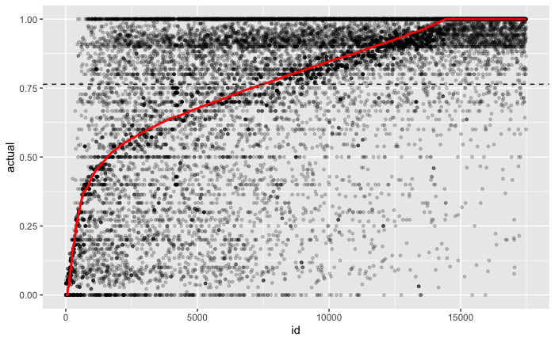

```r
tibble(
  actual = y_valid,
  pred = model %>% predict(x_valid) %>% as.vector()
  ) %>%
  mutate(pred = case_when(
    pred < 0 ~ 0,
    pred > 1 ~ 1,
    TRUE ~ pred
  )) %>%
  arrange(pred) %>%
  mutate(id = row_number()) %>%
  ggplot(aes(x = id)) +
  geom_point(aes(y = actual), size = 1, alpha = 0.2) +
  geom_line(aes(y = pred), color = "red", size = 1) +
  geom_hline(yintercept = avg, lty = "dashed")
```